# CN CHAPTER 2

# 📡 **Digital Communication Notes** 📡

## **1. Parallel vs. Serial Communication**

### **Parallel Communication**

- **Definition**: Transmits **multiple bits simultaneously** across **multiple channels** (e.g., 8 bits at once).
- **Keywords**: Speed 🚀, Data Skew, Short-Distance.
- **Real-Life Example**:
  - **Internal Computer Buses** (e.g., PCI Express for GPU connections 🎮).
  - **Printer Ports** (LPT ports for fast data transfer to printers 🖨️).
- **Advantages**:
  - **High Speed**: Ideal for short-distance communication (e.g., RAM ↔︎ CPU).
  - **Simple Programming**: No need for bit sequencing.
- **Disadvantages**:
  - **Data Skew**: Longer cables cause timing issues (e.g., bits arrive out of order ❌).
  - **Costly**: Requires multiple wires.

### **Serial Communication**

- **Definition**: Sends data **one bit at a time** over a **single channel**.
- **Keywords**: Sequential 🔄, Reliability, Long-Distance.
- **Real-Life Example**:
  - **USB 3.0** (high-speed data transfer for external drives 💾).
  - **Ethernet Cables** (Cat6 for stable internet 🌐).
- **Advantages**:
  - **Cost-Effective**: Fewer wires = cheaper for long distances (e.g., undersea cables 🌊).
  - **Less Interference**: Single channel reduces crosstalk.
- **Disadvantages**:
  - **Slower for Short Distances**: Latency due to sequential transmission.

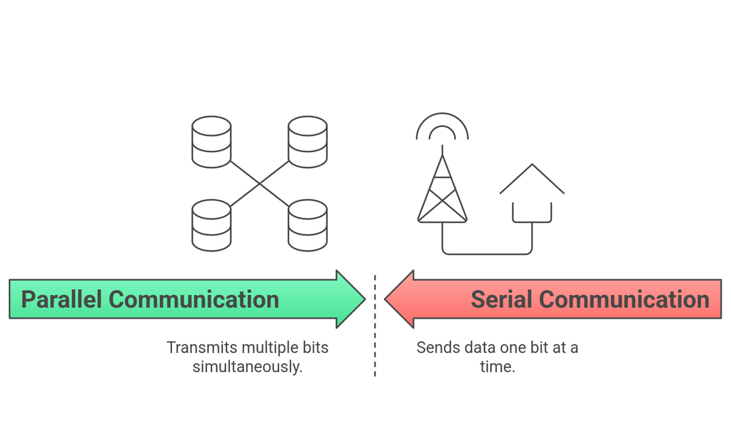

## **2. Synchronous vs. Asynchronous Transmission**

### **Synchronous Transmission**

- **Definition**: Data sent in **fixed-size blocks** with **shared clock signals** ⏱️.
- **Keywords**: Full-Duplex, No Gaps, Frames.
- **Real-Life Example**:
  - **Live Streaming** (Netflix/YouTube 📺: continuous data flow).
  - **SPI Protocol** (used in Arduino sensors 🌡️).
- **Advantages**:
  - **High Efficiency**: No start/stop bits → more data per frame.
- **Disadvantages**:
  - **Clock Synchronization Required**: Complex setup.

### **Asynchronous Transmission**

- **Definition**: Data sent in **variable-sized packets** with **start/stop bits** 🛑.
- **Keywords**: Flexibility, Overhead, UART.
- **Real-Life Example**:
  - **Keyboard Input** (typing on a PC ⌨️).
  - **HTTP Requests** (web browsing 🌍).
- **Advantages**:
  - **No Shared Clock**: Devices can have different speeds (e.g., GPS modules 🛰️).
- **Disadvantages**:
  - **Overhead Bits**: 20-30% of bandwidth wasted on control bits.

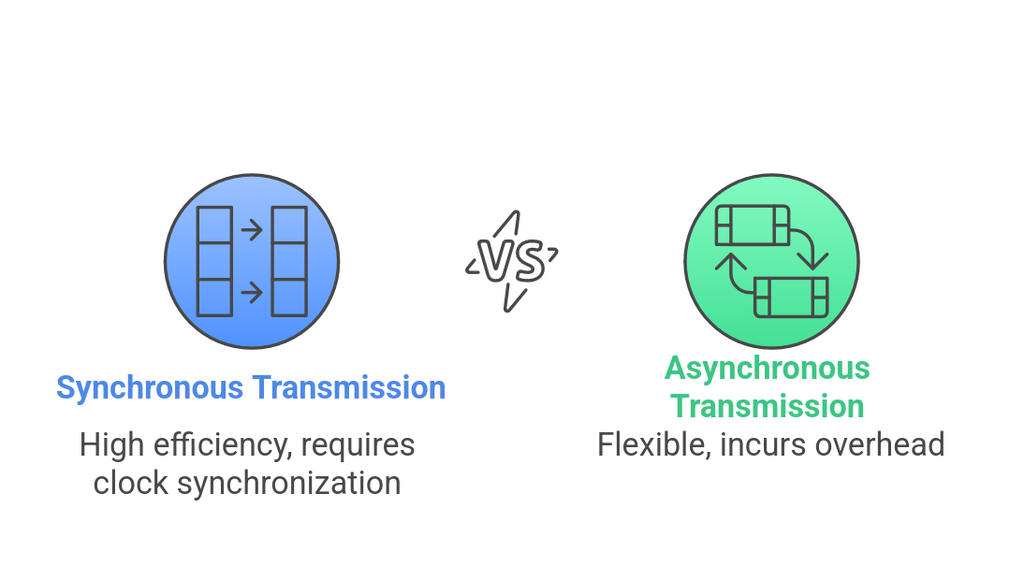

## **3. Modes of Communication**

### **Simplex Mode**

- **Definition**: **One-way** communication (send **OR** receive).
- **Keywords**: Unidirectional, No Feedback.
- **Real-Life Example**:
  - **FM Radio** 📻 (station → listeners; no reverse).
  - **Temperature Sensors** 🌡️ (sensor → display unit).
- **Advantage**: Full bandwidth for one direction.

### **Half-Duplex Mode**

- **Definition**: **Two-way** but **not simultaneous** 🔄.
- **Keywords**: Walkie-Talkie, Push-to-Talk.
- **Real-Life Example**:
  - **Air Traffic Control** 🛩️ (pilot ↔︎ tower; one speaks at a time).
  - **Zigbee Networks** (smart home devices 🏠).
- **Disadvantage**: **Collision Risk** if both transmit (e.g., walkie-talkie chaos 📢).

### **Full-Duplex Mode**

- **Definition**: **Simultaneous two-way** communication 🗣️👂.
- **Keywords**: Telephone, VoIP, Duplex Channels.
- **Real-Life Example**:
  - **Zoom Calls** 🎥 (talk and listen while sharing screen).
  - **4G/5G Networks** 📱 (download & upload simultaneously).
- **Advantage**: **Zero Delay** in bidirectional communication.

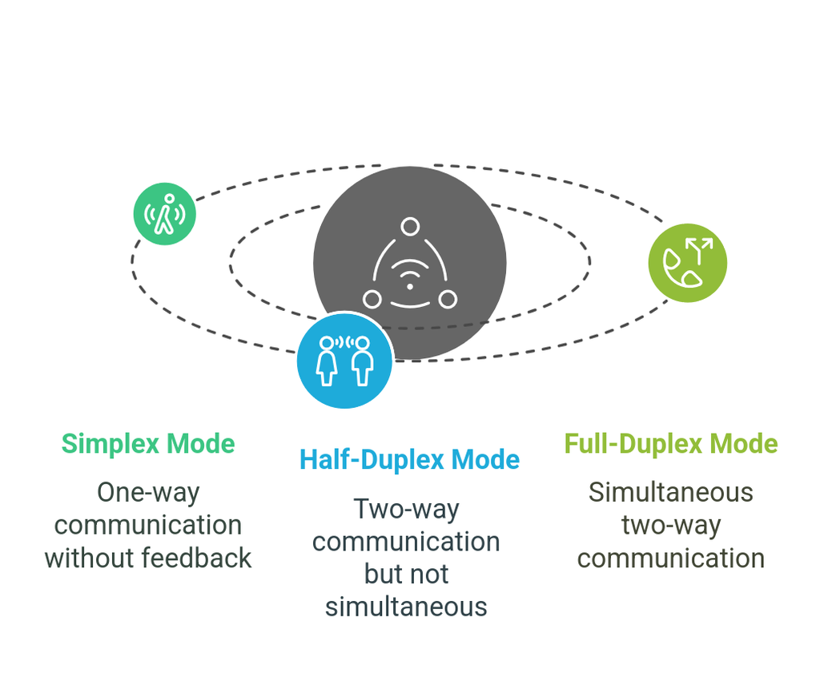

## **4. Multiplexing Techniques**

### **Frequency-Division Multiplexing (FDM)**

- **Definition**: Divides bandwidth into **frequency bands** 📶.
- **Keywords**: Analog Signals, Radio Stations.
- **Real-Life Example**:
  - **Cable TV** 📺 (multiple channels on one cable).
  - **Wi-Fi Channels** (2.4 GHz vs. 5 GHz bands 📡).
- **Disadvantages**:
  - **Crosstalk**: Overlapping frequencies cause noise (e.g., old FM radios 🔇).

### **Time-Division Multiplexing (TDM)**

- **Definition**: Allocates **time slots** to users 🕒.
- **Keywords**: Digital Signals, Efficiency.
- **Types**:
  - **Synchronous TDM**: Fixed slots (e.g., **T1 Lines** for offices 🏢).
  - **Asynchronous TDM**: Dynamic slots (e.g., **Internet Packets** 🌐).
- **Real-Life Example**:
  - **4G LTE Networks** 📶 (multiple users share the same frequency).

### **Wavelength-Division Multiplexing (WDM)**

- **Definition**: Uses **different light wavelengths** in fiber optics 🌈.
- **Real-Life Example**:
  - **Submarine Internet Cables** 🌊 (terabits of data via light pulses).

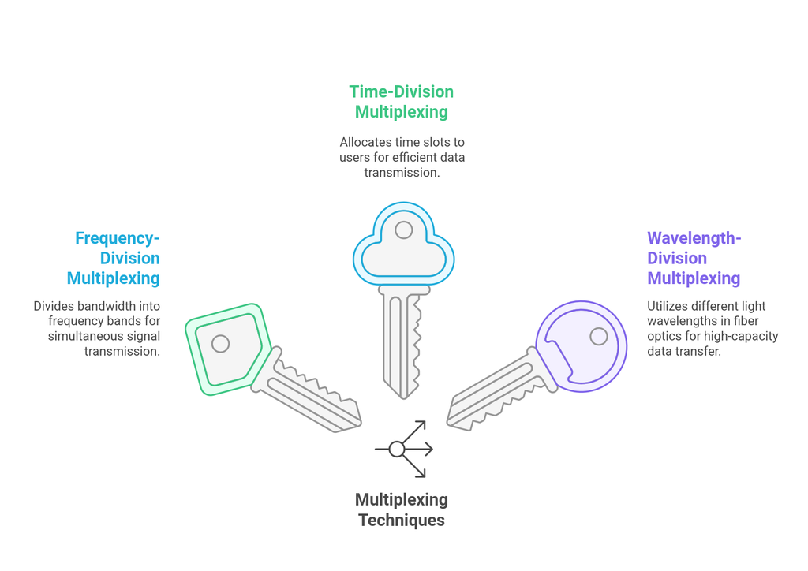

## **5. Communication Media**

### **Guided Media**

1. **Twisted Pair Cable**:
   - **UTP**: Unshielded (Cat6 for offices 🏢; 1 Gbps speed).
   - **STP**: Shielded (industrial robots 🤖; reduces EMI).
2. **Coaxial Cable**:
   - **Types**:
     - **Baseband** (single signal; e.g., CCTV cameras 🎥).
     - **Broadband** (multiple signals; e.g., cable internet 📶).
3. **Fiber Optic**:
   - **Single-Mode**: Long-distance (e.g., intercity networks 🌆).
   - **Multi-Mode**: Short-distance (e.g., LANs 🏠).

### **Unguided Media**

4. **Radio Waves**:
   - **Applications**:
     - **Bluetooth** 🎧 (short-range).
     - **Satellite TV** 📡 (geostationary satellites).
5. **Infrared**:
   - **Example**: **TV Remotes** 📺 (line-of-sight required 🔦).
   - **Limitation**: Sunlight interferes outdoors ☀️.
6. **Microwaves**:
   - **Example**: **Radar Systems** 🚁 (air traffic control).

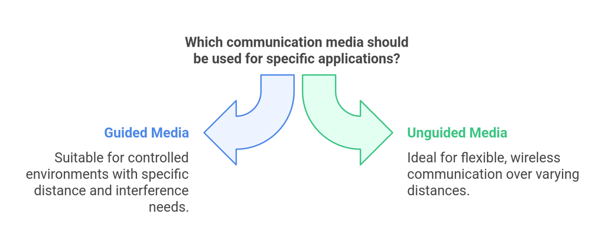

## **6. Switching Techniques**

### **Circuit Switching**

- **Phases**:
  1. **Establishment** (dialing a number ☎️).
  2. **Data Transfer** (voice call 🗣️).
  3. **Termination** (hanging up 📴).
- **Real-Life Example**: **Traditional Landlines** (dedicated path for entire call).
- **Disadvantage**: **Inefficient Bandwidth** (e.g., silent gaps in calls 🤫).

### **Message Switching**

- **Definition**: **Store-and-Forward** entire messages ✉️.
- **Real-Life Example**: **Old Email Systems** (messages routed via servers 📨).
- **Advantage**: **Traffic Management** (prioritize critical messages 🚨).

### **Packet Switching**

- **Types**:
  - **Datagram**: Independent packets (e.g., **IP Networks** 🌐).
  - **Virtual Circuit**: Predefined path (e.g., **ATM Networks** 💳).
- **Real-Life Example**: **Streaming Netflix** 🎬 (packets take varied paths for speed).
- **Advantage**: **Fault Tolerance** (if one path fails, use another 🛠️).

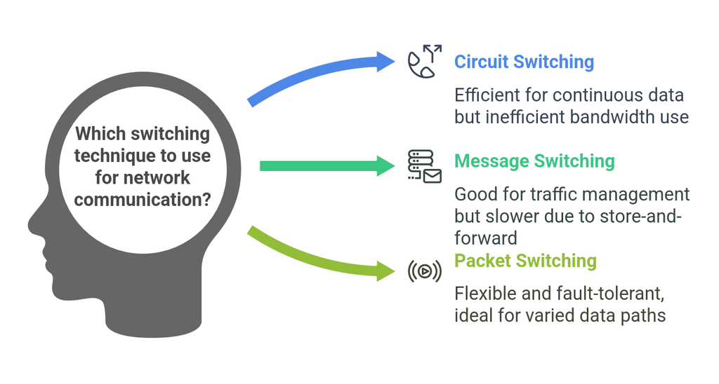